# Geopandas Exercise

- Create a geodataframe from a CSV file with coordinate columns
- Create a geodataframe from a shapefile
- Exploring and Plotting geodataframes
- Attribute subset
- Dissolving features
- Spatial subsets
- Spatial joins

```python
#Read in the packages
import pandas as pd
import geopandas as gpd
from shapely.geometry import Point
```

### 1. Fetching and exploring spatial data

► **Q1.1** Read the `Permitted_Animal_Facilities.csv` file into a geodataframe called `gdf_animal`. Assume the coordinate columns (`Location Lat Num` and `Location Long Num`) use the NAD 1983 coordinate reference system (WKID/EPSG = 4269).

```python
#Read the CSV into a Pandas dataframe

#Construct geometries from the dataframe's coordinate columns

#Create a geodataframe from the dataframe, the geometry, and the coordinate reference system
gdf_animal =
```

► **Q1.2** Plot the geodataframe as a simple point map.

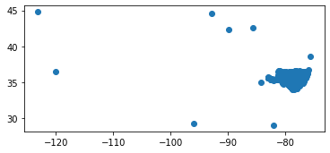

```python
#Plot the geodataframe as simple points
```

► **Q1.3** Subset points where values in the `State` column equal "NC" into a new dataframe called `gdf_animals_nc`.

```python
#Subset NC records
gdf_animals_nc =
```

► **Q1.4** Plot the subset features. For full credit:

- Assign different colors to each unique value in the `Permit Type` column
- Use the `Set3` color map
- Draw markers something other than the default, using an opacity of 0.4
- Set the figuire size to 12 x 6

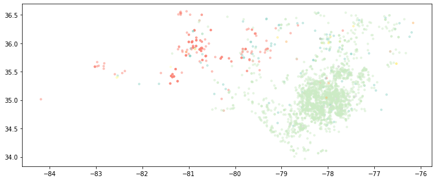

```python
#Plot the NC records
```

► **Q4** Read the `HUC12.shp` shapefile into a geodataframe named `gdf_HUC12`

```python
#Read in the HUC12 feature class
gdf_HUC12 =
```

► **Q5** Show whether the HUC_12 geodataframes has the same coordinate reference system as the Animal Permit one.

```python
#Reveal whether this and the animal permit geodataframe
# share the same coordinate reference system
```

```
True
```

► **Q6** Plot the features so that each HUC_10 appears as a different color

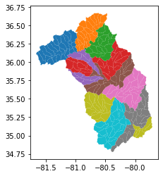

```python
#Plot the features, showing HUC_10s as different colors
```

► **Q7** Dissolve HUC_12 features based on the HUC_10 attribute, naming the output `gdf_HUC10`. The output should include the sum of the `ACRES` column and the first `HU_10_NAME` value.

```python
#Dissolve HUC12 features on the HUC_10 attributes & display
gdf_HUC10 =
gdf_HUC10.head()
```

| HUC_10 | geometry | ACRES | HU_10_NAME |
| --- | --- | --- | --- |
| 0304010101 | POLYGON ((-81.39655 36.05652, -81.39622 36.056... | 112698.0 | Headwaters Yadkin River |
| 0304010102 | POLYGON ((-81.31415 36.00443, -81.31416 36.004... | 120847.0 | W Kerr Scott Reservoir-Yadkin River |
| 0304010103 | POLYGON ((-81.14146 36.05536, -81.14154 36.055... | 134933.0 | Reddies River-Yadkin River |
| 0304010104 | POLYGON ((-81.00502 36.14152, -81.00515 36.141... | 117712.0 | Roaring River-Yadkin River |
| 0304010105 | POLYGON ((-80.78422 36.39568, -80.78405 36.395... | 69230.0 | Mitchell River |

► **Q8** Subset the animal permit locations that fall within the HUC_10 features. Save the output as `gdf_HUC_animals`

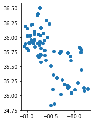

```python
#Intersect the two dataframes
gdf_HUC_animals =

#Plot
```

► **Challenge question**: The `gdf_HUC_animals` dataframe now includes the HUC 10 name (in the `HU_10_NAME` attribute) for each animal permit location. We can now count the total number of animal permits in each HUC 10. Furthermore, because the Animal Permit data includes an attribute of the number of animals (`Allowable Count` attribute), we can also compute the total number of permitted animals for each HUC 12.

With this information, see if you can:

- **C1** Create a bar plot showing the number of permits by HUC 10
  - *TIP*: The `value_counts()` function can be useful here...
- **C2** Create a bar plot showing the total allowable count of animals in each HUC 10
  - *TIP*: You'll need to aggregate your `gdf_HUC_animal` data either via Pandas' `groupby` or GeoPandas' `dissolve` function... to compute the sum of allowable counts across each HUC10.
  - *TIP*: To make a non-map plot from a geodataframe, you'll need to convert it to a Pandas dataframe (`pd.DataFrame(<geoDataFrame>)`)
- **C3** Create a plot of HUC10s colored by the number of permits or the number of allowed animals in each.
  - _I actually give you the code to plot # of permits per HUC_10 (below), but see if you can alter the code to show the total allowable count by HUC_10. Then, see if you can divide the values by area to compute density of permits and/or allowable count in each HUC*10...*

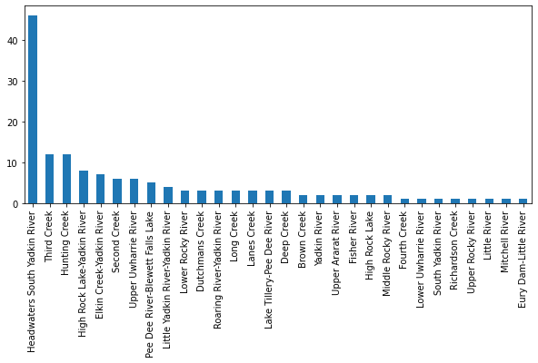

```python
#Create a bar plot of # of permits in each HUC 10
```

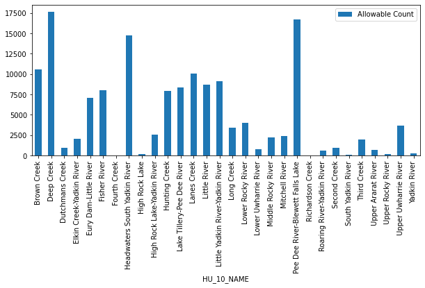

```python
#Create a bar plot of the total # of allowable animals in each HUC 10
```

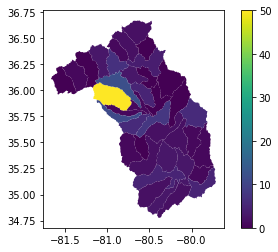

```python
## Plot the # of permits in each HUC 10

#Spatially join the animal permits to each HUC 10 feature
gdf_sjoin = gpd.sjoin(left_df=gdf_HUC10,
                      right_df=gdf_animal,
                      how='left',
                      op='contains')
#Dissolve on HUC 10
gdf_sjoin_HUC10 = gdf_sjoin.dissolve('HU_10_NAME',aggfunc={'Allowable Count':'count','ACRES':'sum'})

#Plot based on Allowable Count attribute
gdf_sjoin_HUC10.plot('Allowable Count',legend=True);
```

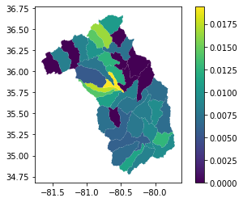

```python
#Plot the # of permits per acre
```